# Repguide user’s guide

## Calculating guide combinatorics

We calculate binding profiles of all possible combinations for up to 8 distinct guides by typing:

```r
gs <- addCombinations(gs, # our guideSet
                      n_guides = 8, # maximal number of guides to consider
                      method = 'max') # combinations with max on-targets are selected
```

Having added the combinded binding statistics to our *guideSet*, we can inspect them by entering:

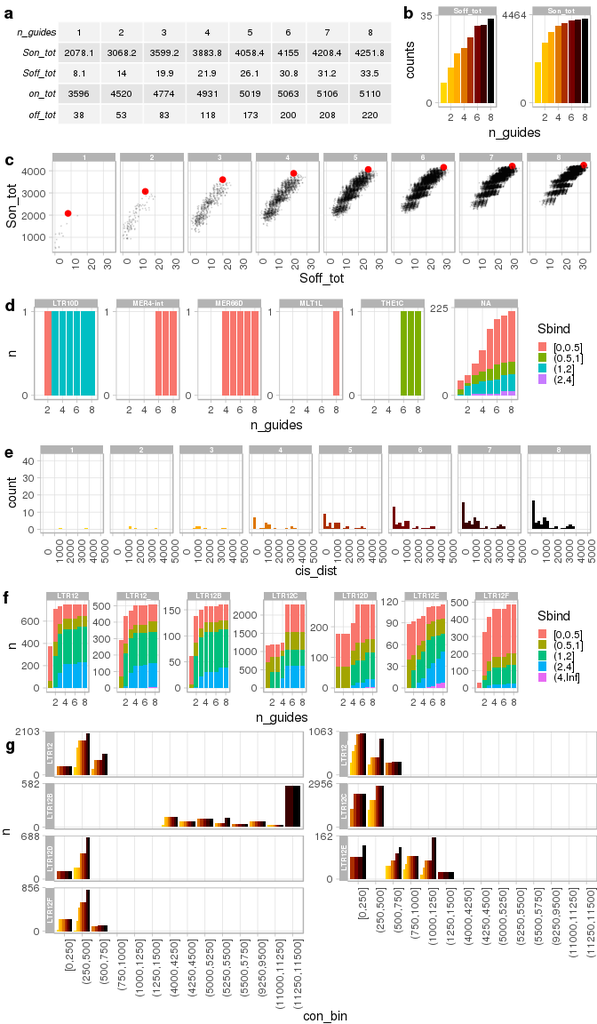

```r
gs <- plotCombinations(gs)
```

## Exporting the results

We can finally save the relevant results and plots of our guideSet to a specified directory:

```r
export(gs,
       outdir = tempdir(),
       dpi = 320, # image resolution,
       workspace = FALSE) # don't save guideSet as workspace
Sys.time()
```

Executing the command will create a subdirectory in the specified outdir (or current working directory if `force = TRUE`) and writes all output files to it.

```r
knitr::include_graphics(img1_path)
```

[output not shown]

# References